# Boletim Sou da Paz Analisa 2022 - Panorama

Instituto Sou da Paz

2023-07-31

SUMÁRIO

APRESENTAÇÃO

O Instituto Sou da Paz acompanha as estatísticas criminais divulgadas pela Secretaria da Segurança Pública de São Paulo (SSP/SP) desde 2012, a fim de contribuir para a melhor compreensão das dinâmicas criminais e atividades policiais no estado de São Paulo e em suas grandes regiões - Capital, Grande São Paulo e Interior. Além dos dados mensalmente divulgados pela SSP/SP, são consideradas informações produzidas pelas Corregedorias das Polícias Civil e Militar do Estado de São Paulo publicadas no Diário Oficial e dados obtidos via Lei de Acesso à Informação (LAI), fornecidos pela Coordenadoria de Análise e Planejamento (CAP) da SSP/SP e pela Polícia Civil.

Desde 2022 o Boletim Sou da Paz Analisa tem uma periodicidade semestral e, nesta edição referente ao ano de 2022, aborda os principais indicadores de crimes violentos, especificamente os homicídios dolosos, latrocínios, estupros, roubos, além dos homicídios e agressões contra mulheres no estado no último ano.

Essa edição do Boletim traz uma análise especial sobre o perfil da letalidade policial no estado de São Paulo entre os anos de 2018 e 2022, ou seja, intervalo que abarca tanto o período de maior letalidade das polícias na história recente do estado, como aquele de redução mais abrupta das mortes cometidas por policiais a partir da implementação de uma série de medidas de controle do uso da força letal pela Polícia Militar de São Paulo. Exploramos nesta análise especial dados das corregedorias das polícias paulistas, da SSP/SP e do Ministério Público de São Paulo para traçar o perfil etário e racial das vítimas de letalidade policial, assim como comparações entre as dinâmicas de letalidade policial e perfis das vítimas em uma perspectiva comparada entre batalhões da polícia militar que utilizam as Câmeras Operacionais Portáteis (COP) e aqueles que ainda não adotaram esta ferramenta de controle das atividades dos policiais.

O objetivo é demonstrar o efeito concreto e eficaz de medidas de controle do uso da força pelas polícias, não somente no número de pessoas mortas, que certamente é a principal justificativa para a implementação destas ações, mas também na queda da vitimização policial e na mudança substantiva do perfil das demais vítimas.

Criminalidade Violenta

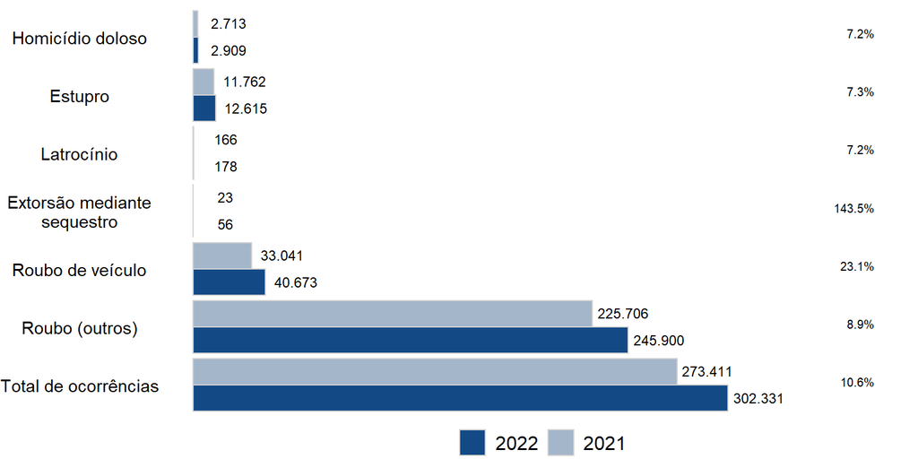

Em 2022, a criminalidade violenta no estado de São Paulo apresentou aumento em todos os tipos criminais analisados, porém a extorsão mediante sequestro é, entre todos, o crime que teve o maior acréscimo, dobrando o número de casos na comparação entre os anos de 2021 e 2022. Esta elevação pode ter como um dos principais fatores uma nova dinâmica, chamada de “sequestros do pix”, modalidade de crime que surgiu com o advento e popularização desta tecnologia de transferências monetárias de forma imediata, lançada pelo Banco Central em 2020. Por sua vez, as ocorrências de outros crimes graves contra a vida e a dignidade, os homicídios dolosos, latrocínios e estupros, tiveram aumentos de cerca de 7% em 2022, o que evidencia a piora substantiva do cenários dos crimes violentos no estado de São Paulo no ano passado. Os crimes patrimoniais violentos tiveram aumentos ainda mais substantivos em 2022 em comparação com 2021, sobretudo os roubos de veículos, com um intenso aumento de 23% no último ano – foram 40.673 ocorrências de roubos de veículos registradas no estado em 2022, o que significa uma média de cerca de 111 veículos roubados por dia durante o ano.

Letalidade Violenta

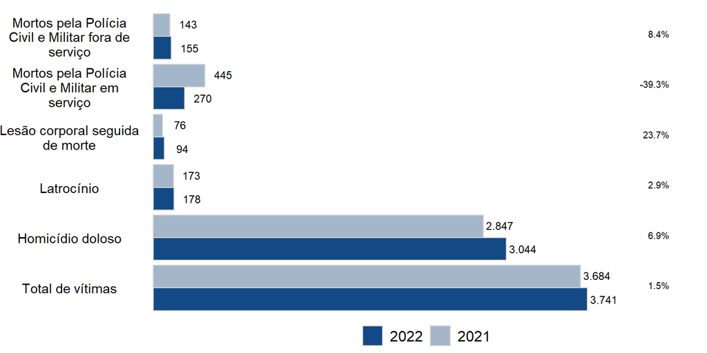

Homicídios Dolosos

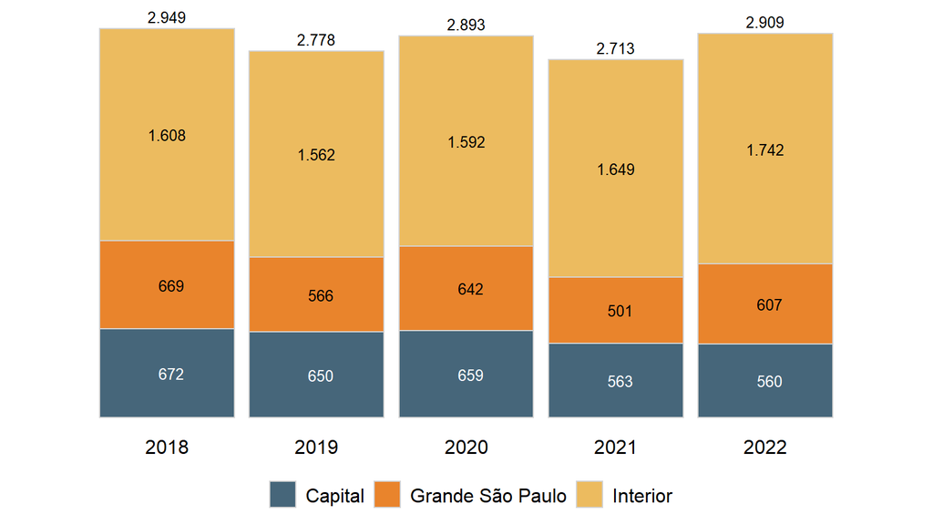

O ano de 2022 registrou 2.909 ocorrências de homicídio doloso, um número muito próximo daquele registrado quatro anos antes em 2018.No entanto, na comparação com o ano anterior, em 2022, o estado de São Paulo registrou um aumento de 7,2% nas ocorrências de homicídios. Os municípios da Grande São Paulo registraram um aumento de 21,2% nas ocorrências de homicídios dolosos entre 2022 e 2021, enquanto o Interior do estado apresentou um crescimento de 5,6% nas ocorrências desses crimes. É importante destacar que o Interior do estado de São Paulo registrou no último ano um total de 1.742 ocorrências de homicídios dolosos, isso significa que o Interior de São Paulo concentrou 59,8% das 2.909 ocorrências de homicídios dolosos no estado neste ano, ainda que estes municípios concentrem aproximadamente 12,1 milhões de habitantes, ou seja, cerca de um quarto da população do estado de São Paulo.

Homicídios no Interior do estado

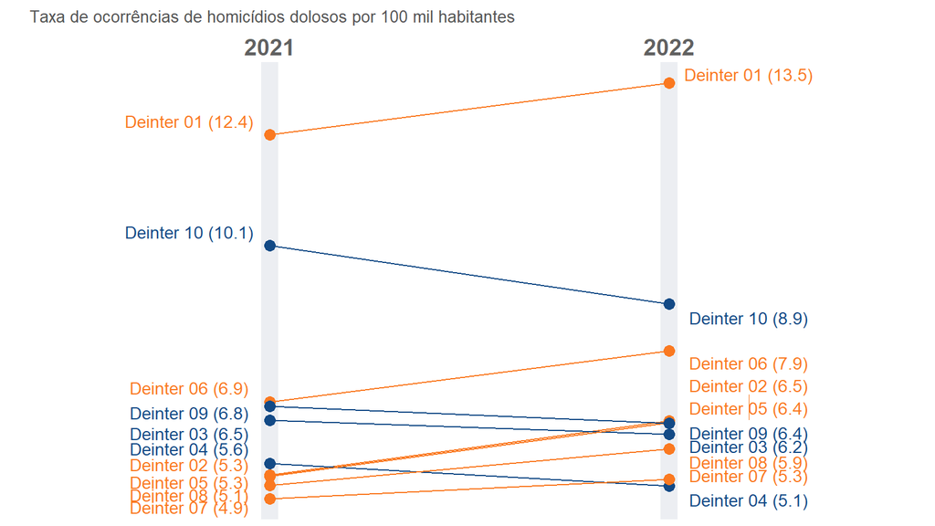

Latrocínio

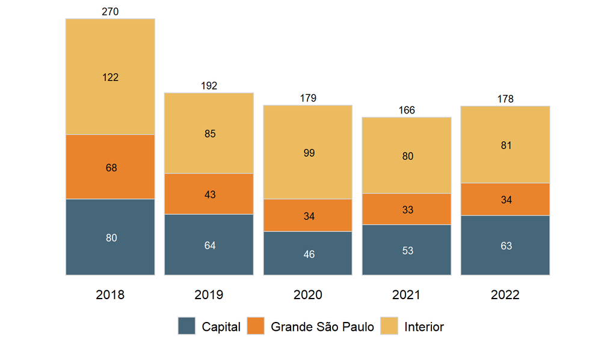

Lesão corporal de mulheres

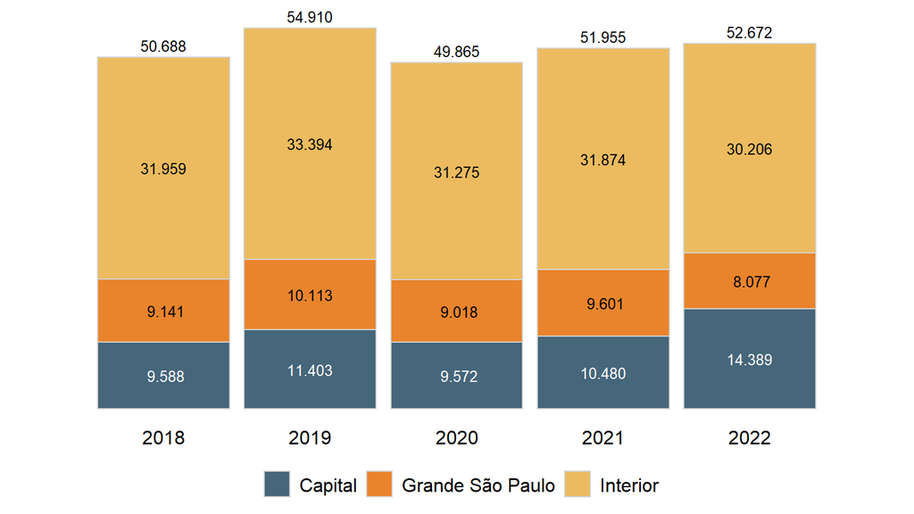

Foram registrados em 2022 no estado de São Paulo 52.672 ocorrências de lesão corporal de mulheres, um aumento residual de 1,3% no número de registros em comparação com o ano de 2021. Este montante significa que, em média, foram registradas cerca de 144 ocorrências de lesão corporal de mulheres por dia no estado durante 2022. Dentre as macrorregiões analisadas, somente a Capital apresentou aumento em relação ao ano anterior. O município de São Paulo registrou 14.389 ocorrências de lesão corporal de mulheres, 3.909 registros a mais que em 2021, um aumento de 37,2% neste período. Por sua vez, tanto o Interior, quanto a Grande São Paulo tiveram queda nas notificações deste crime em 2022. Ainda assim, o aumento progressivo que vem sendo observado neste tipo de crime no estado, especialmente na Capital, denota a urgência de se pensar políticas públicas para a redução efetiva dos casos de lesão corporal contra a mulher.

Feminicídio

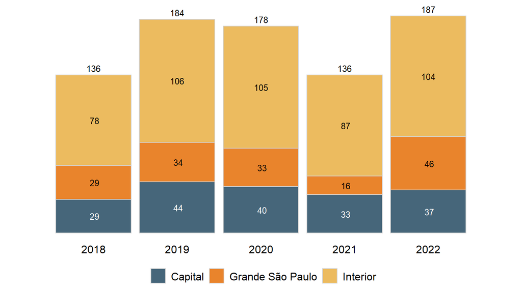

Após uma redução em 2021, as ocorrências de feminicídio voltaram a aumentar 37,5% em 2022, alcançando o maior patamar dos últimos cinco anos. É importante destacar o aumento significativo das ocorrências de feminicídio na macrorregião da Grande São Paulo: foram 46 ocorrências deste crime em 2022, um aumento de 187% na comparação com 2021, e de 58,6% em relação ao número destes crimes cometidos em 2018. Das 187 ocorrências de feminicídios cometidos em 2022 no estado de São Paulo, 24,6% foram cometidos na macrorregião da Grande São Paulo, 19,7% na Capital e 55,6% nos municípios do Interior. Além disso, os 187 casos de feminicídio representam 45% do total de homicídios dolosos contra mulheres cometidos no estado em 2022.

Estupro

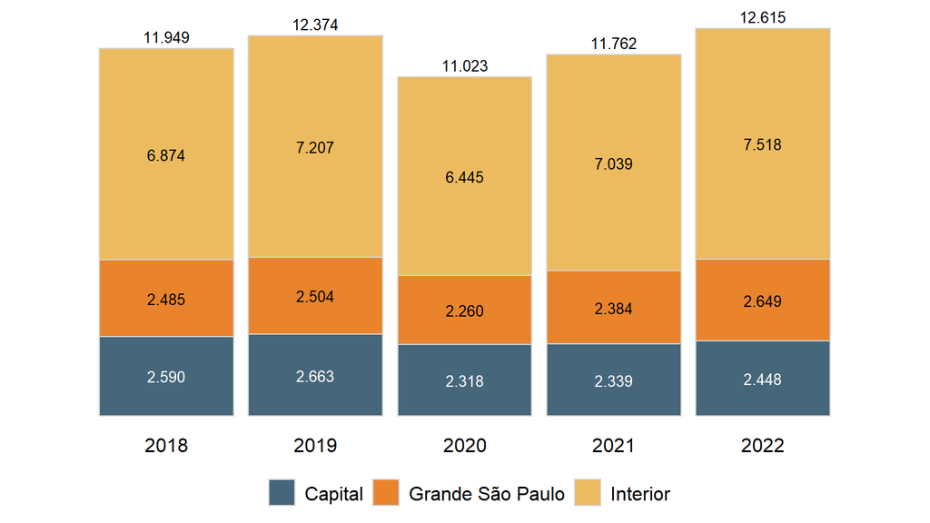

Roubos (Total)

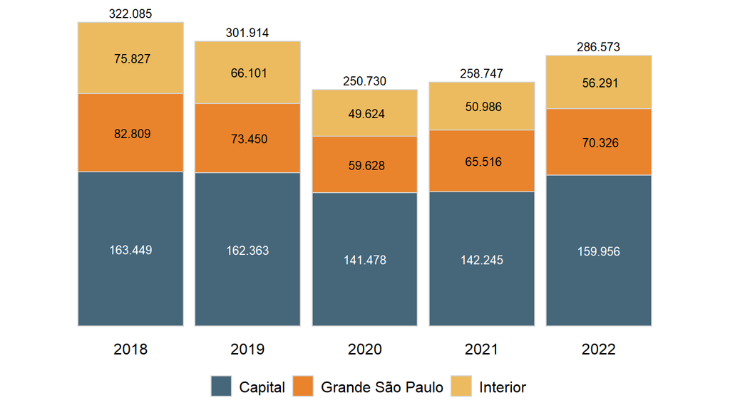

O ano de 2022 terminou com um total de 286.573 ocorrências total de roubos, ou seja, a soma dos chamados roubos (outros) e os roubos de veículos, em todo o estado de São Paulo, um volume de ocorrências 10,7% maior que o total de 258.747 ocorrências de roubo registrados em 2021. Isso significa que, em média, foram registrados no estado cerca de 785 ocorrências totais de roubos por dia durante o último ano. Ainda que o montante de roubos registrados no estado em 2022 ainda seja menor do que de anos anteriores à pandemia de Covid-19, desde 2020 os roubos têm aumentado em todas as macrorregiões do estado. Especificamente na comparação entre 2022 e 2021, o maior aumento foi na Capital paulista, com mais 12,4% de ocorrências de roubos registradas em 2022. A Grande São Paulo teve um aumento no último ano de 7,3% nas ocorrências registradas deste crime, e o Interior, um crescimento de 10,4% nas ocorrências de roubos.

Roubos (Total) na capital

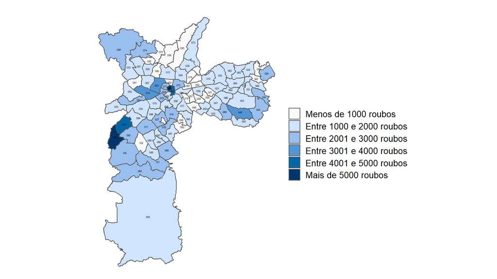

Dentre os 103 distritos policiais da cidade de São Paulo, somente 10 DPs foram responsáveis por 25,6% de todas as ocorrências de roubo (total) na capital do estado em 2022. O 03 DP, Campos Elísios, registrou o maior número de roubos, um total de 7.245 ocorrências.

A região do centro também teve outros dois DPs entre os 10 distritos policiais com maior número de registros de ocorrências de roubos (total). O 01 DP, Sé, ficou na terceira posição com 4.815 roubos registrados e o 12 DP, Pari, na oitava colocação. Na zona sul, o 47 DP, Capão Redondo, 37 DP, Campo Limpo, 92 DP, Parque Santo Antônio foram os distritos policiais com mais roubos. Na zona oeste teve o 14 DP, Pinheiros, 23 DP, Perdizes e 78 DP, Jardins foram os distritos com mais ocorrências de roubos. O 49 DP, São Mateus, é o único dos 10 distritos policiais com mais registros de roubos da zona leste.

Recomendações

Análise Especial - Perfil da letalidade policial no estado de São Paulo 2018 - 2022

Nesta seção faremos uma análise do perfil da letalidade policial no estado de São Paulo, entre os anos de 2018 e 2022, intervalo que abarca tanto o período de maior letalidade das polícias na história recente do estado, como o período de redução mais abrupta das mortes cometidas por policiais, a partir da implementação de uma série de medidas de controle do uso da força letal pela Polícia Militar do Estado de São Paulo.

É importante observar a existência de dois marcos relevantes no período que devem ser considerados na análise e interpretação dos dados sobre a letalidade e vitimização policial no estado. O primeiro deles é a transição dos gestores estaduais no período, já que o governo do estado foi ocupado por Márcio França (PSB, 2018), João Dória (PSDB, 2019-2022), e por Rodrigo Garcia (PSDB, 2022). A implementação das medidas de controle do uso da força pela Polícia Militar começaram a ser implementadas em meados de 2020, no segundo ano da gestão Dória.

O primeiro semestre de 2020 também foi o início de outro marco que afetou diretamente as dinâmicas letais no estado: a pandemia de Covid-19, cujas medidas de isolamento social foram decretadas ainda em março de 2020, impactando fortemente a capacidade de circulação da população, as dinâmicas criminais e, especificamente em São Paulo, marcando um dos semestres com mais ocorrências de letalidade policial na história recente do estado.

Porém, na segunda metade de 2020 começaram a ser implementadas pela Polícia Militar do Estado de São Paulo uma série de medidas para garantir o controle do uso da força e reduzir sua letalidade. Dentre estas ações, se destaca o programa Olho Vivo, em que Câmeras Operacionais Portáteis (COP) passaram a ser utilizadas pela corporação. As análises sobre a letalidade e vitimização policial apresentadas nesta seção, frequentemente apontam o ano de 2020 como um ponto de virada, não apenas para a redução das mortes cometidas e sofridas por policiais em serviço, mas também de mudanças substantivas no perfil destas ocorrências.

Como diferentes estudos têm demonstrado ao longo dos anos, a letalidade policial tem uma participação relevante na composição dos crimes violentos letais e nos altos índices de assassinatos registrados no país, e o estado de São Paulo era um dos maiores exemplos desta alta participação da letalidade policial nas mortes violentas. Tamanha letalidade no exercício do trabalho policial tem sido frequentemente justificada pelas próprias policiais e outros atores sociais, como uma espécie de resposta frente à organização de grupos criminais, ao controle territorial exercido por facções, ou ainda, pelos altos índices de roubos verificados em diferentes regiões do país. Por outro lado, essa violência vêm sendo contestada juridica e socialmente por diversos atores da sociedade civil, especialmente pelo movimento negro, tendo em vista o perfil racial das vítimas e a localização geográfica de operações policiais com alta mortalidade, que impactam sistematicamente e de maneira desproporcional as populações periféricas e de baixa renda.

Do ponto de vista da Segurança Pública, o debate sobre a letalidade da forças policiais destaca ainda, como o uso excessivo da força e a própria forma de atuação não só falhou em apresentar resultados efetivos no combate à criminalidade violenta e ao narcotráfico, como também é determinante no aumento das ocorrências de confrontos letais entre policiais e criminosos, que por vezes vítima também a população que reside em áreas de conflito.

O programa Olho Vivo e as medidas de controle do uso da força pela PMSP

Metodologia

As análises sobre os perfis da letalidade e vitimização policial que se seguem neste relatório foram elaboradas a partir de dados sobre mortes que envolvem policiais no estado produzidos por três órgãos distintos. São eles, as corregedorias das polícias do Estado de São Paulo, a própria Secretaria da Segurança Pública de São Paulo, e finalmente, o Ministério Público de São Paulo.

Historicamente, as análises sobre a letalidade e vitimização policial produzidas pelo Instituto Sou da Paz utilizam os dados produzidos pelas Corregedorias da Polícia Civil e da Polícia Militar do Estado de São Paulo, e divulgados mensalmente no Diário Oficial. A prioridade para a utilização destes dados se dá pelo alto grau de confiabilidade e pelo processo de validação que estes passam. No entanto, as Corregedorias divulgam somente números agregados, ou seja, não disponibilizam os microdados, de forma que não é possível analisar elementos do perfil das ocorrências de letalidade e vitimização policial (como por exemplo, idade e raça/cor das vítimas, local, etc.) a partir exclusivamente desta fonte.

Por sua vez, as informações do perfil das ocorrências e das vítimas foram adquiridas através dos microdados de Morte em Decorrência de Intervenção Policial fornecidos em transparência ativa pela SSP/SP em sua plataforma de Estatísticas Criminais. Também foi solicitado junto à secretaria, via Lei de Acesso à Informação, a complementação destes dados com informações que: (i) possibilitasse identificar o batalhão da PMESP no qual os policiais militares estavam lotados no momento da ocorrência, e (ii) uma listagem de quais batalhões da Polícia Militar do Estado de São Paulo haviam implementado as câmeras operacionais portáteis (COP) no contexto do programa Olho Vivo, e quando esta implementação ocorreu. No entanto, a disponibilização destes dados adicionais foi indeferida pela SSP/SP, sob o argumento que estas informações eram de “caráter estratégico para as políticas de segurança pública” do estado.

Foi somente através da base de dados disponibilizada pelo Grupo de Atuação Especial da Segurança Pública e Controle Externo da Atividade Policial (GAESP) do Ministério Público de São Paulo, que foi possível identificar quais os batalhões dos policiais militares envolvidos em ocorrências de letalidade policial, informação essencial para a realização de uma análise mais aprofundada sobre o efeito do uso das câmeras corporais na atuação policial no estado. Ao verificarmos que a base de dados da SSP/SP possuía uma maior variedade de dados sobre o perfil da ocorrência (ainda que sem o batalhão dos policiais envolvidos), optamos por mesclar estes dois bancos com os microdados de letalidade policial: inicialmente, foi utilizado o registro de dados de ocorrências (RDO) para a identificação das observações sobre uma mesma ocorrência de letalidade policial. No entanto, após a identificação de casos em que o RDO contido na base do MP correspondia ao número do processo interno, não ao número do boletim de ocorrência, foi construída uma variável de identificação a partir mesclagem da data, hora e do município da ocorrência. A partir destas duas variáveis-chave foi possível unificar os bancos de dados da SSP/SP e do GAESP.

Finalmente, por meio da revisão bibliográfica e o acompanhamento da produção recente sobre os impactos do Programa Olho Vivo e das demais medidas de controle do uso da força empregadas pela PMESP a partir de 2020, encontramos uma página do Programa Olho Vivo produzida pela própria Polícia Militar do Estado de São Paulo, voltada para os policiais da ponta, com normativas e materiais educacionais sobre o uso das COP, assim como uma listagem dos 64 dentre os 135 batalhões da PMESP que implementaram as câmeras corporais entre 2020 e 2022. A partir desta listagem, foi possível atribuir no banco de dados quais ocorrências de letalidade policial foram cometidas por batalhões com ou sem câmeras.

Assim, o banco final, utilizado na maior parte das análises do perfil das ocorrências, possui dados sobre 3.437 ocorrências de letalidade policial no período entre 2018 e 2022. Já nas análises macro, ou seja, sobre o número de mortes cometidas e sofridas por policiais por ano e por macrorregião do estado, foi utilizado o banco agregado das corregedorias, que contabiliza 3.603 vítimas para o período.

Panorama da letalidade policia no estado de São Paulo

As mortes cometidas por policiais em serviço reduziram substancialmente após as políticas e novas práticas adotadas pelas polícias (como as câmeras corporais, em 2020). Em contrapartida, as mortes cometidas fora de serviço seguem em caráter de de estabilidade, com notável aumento de 8,4% nos casos registrados em 2022, comparado ao ano anterior. Os casos de vitimização de policiais em folga tiveram atenuado aumento. Foram 52,9% de casos a mais em 2022 comparado a 2021. Já durante o serviço, foram -12,5% de casos registrados. O aumento de mortes cometidas por policiais fora de serviço e de policiais vitimados em folga podem apresentar uma nova dinâmica que necessita de atenção. É necessário verificar as dinâmicas dos fatos (se houve conflito ou outro tipo de delito) e em local aquele policial ocupava no momento da morte cometida ou vitimada (se tentava conter um assalto, ou se fora vítima de assalto, por exemplo). Analisar tais dinâmicas e compreender como a sociedade tem se movimentado para as gestões governamentais manterem o compromisso com a redução dos homicídios no estado.

Letalidade policial por macrorregião

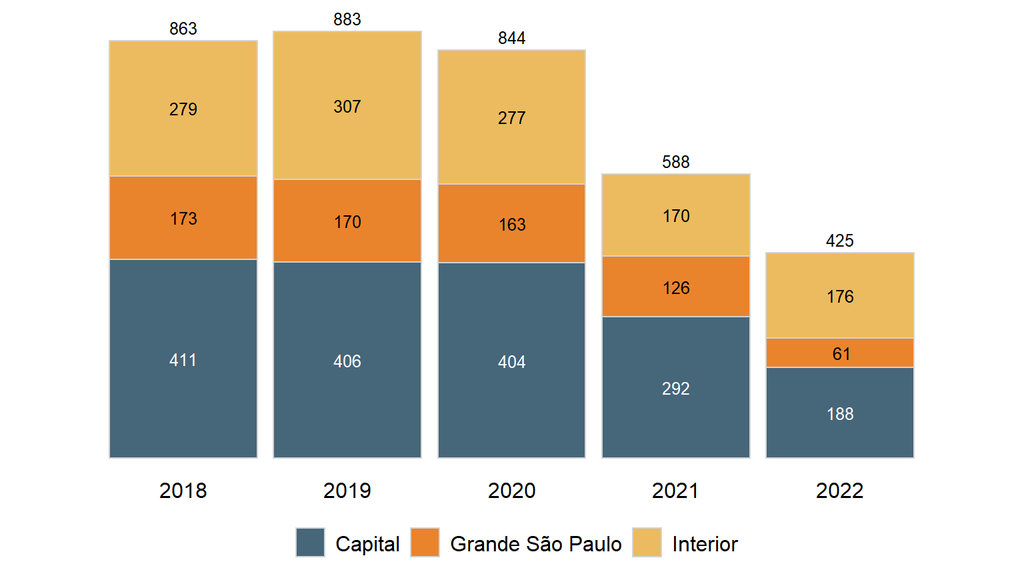

A letalidade policial, ou seja, o número de pessoas mortas por policiais em serviço e de folga, no estado de São Paulo segue em intensa redução desde o ano de 2021. Em 2022, na comparação com o ano anterior, a letalidade policial no estado caiu -27,7%, com 163 pessoas mortas a menos do que em 2021. A redução mais intensa se deu na macrorregião da Grande São Paulo, com uma queda de -51,5% entre os anos de 2021 e 2022, seguida da Capital, com uma redução de -35,6% no mesmo período. Ao observar a série histórica dos últimos 5 anos, a letalidade policial do estado se reduziu pela metade, especificamente -50,7% no número de mortes. Todas as regiões registraram quedas substantivas entre 2018 e 2022, sendo as mais intensas nos municípios da Grande São Paulo (-64,5%) e a Capital (-54,2%).

Letalidade Policial no Interior

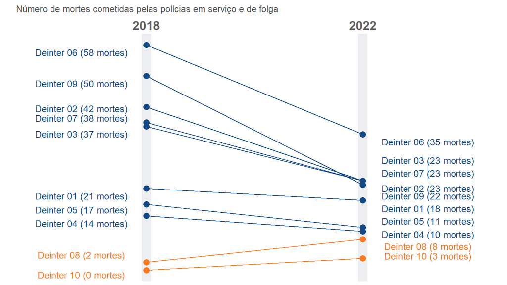

A macrorregião do Interior registrou uma redução de -36,9% das mortes cometidas por policiais entre 2018 e 2022. Dentre os dez Departamentos de Polícia Judiciária de São Paulo Interior (Deinter), oito registraram redução na letalidade policial neste intervalo de 5 anos, e apenas os dois departamentos com menos mortes em 2018 e tiveram crescimento nas mortes cometidas pelas polícias, com destaque negativo para o Deinter 08 - Presidente Prudente, que passou de 2 mortes em 2018 para 8 vítimas em 2022.

As maiores reduções proporcionais se deram no Deinter 09 - Piracicaba, com uma redução de -56% na letalidade policial entre 2018 e 2022 (menos 28 vítimas), e o Deinter 02 - Campinas, que registrou 19 vítimas a menos, uma redução de -45,2%.

Proporção da Letalidade policial em serviço e em folga

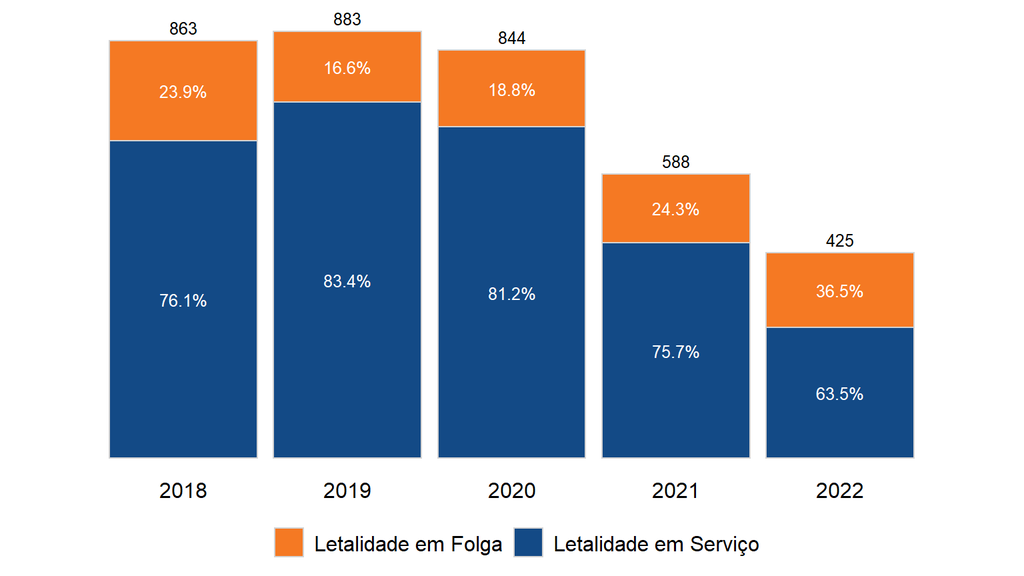

Em relação a situação dos polícias nas ocorrencias de letalidade, a letalidade em serviço permanece representando a maior parcela dos casos. Contudo, houve um aumento da proporção de casos em folga nos últimos dois anos. A letalidade em serviço em 2019 compunha 83,4% dos casos, já em 2022 representa 63,5%, 19,9% a menos. A significativa redução da letalidade policial dos últimos acompanhou também um deslocamento dos casos, aumentando as ocorrências om agentes de segurança em folga, fenômeno que deve ser acompanhado com atenção. Além da implementação do programa Olho Vivo, destacam-se como dinâmicas relevantes para essa mudança o crescimento de mercados de segurança privados.

Vitimização policial por macrorregião

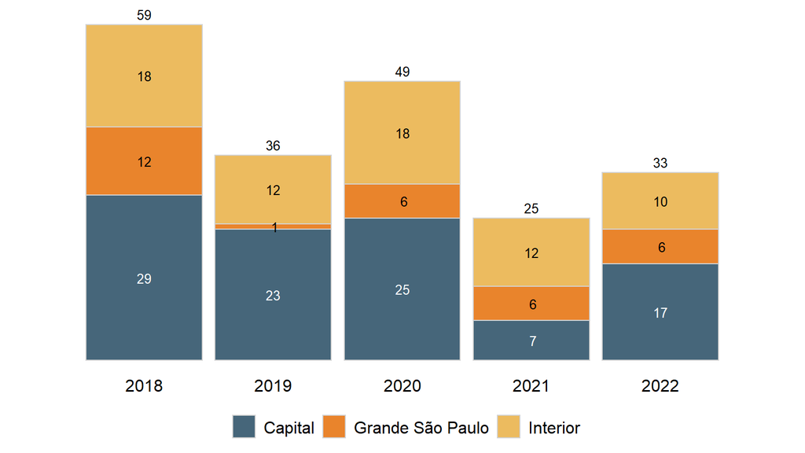

Enquanto a letalidade policial no estado tem se reduzido desde o ano de 2020, a vitimização de policiais, seja em serviço ou de folga, tem oscilado nos últimos cinco anos. De forma geral, o estado teve uma redução de -44% nas vitimização policial entre 2018 e 2022, com 26 policiais mortos a menos no último ano. Já na comparação entre os anos de 2021 e 2022, o estado de São Paulo registrou um aumento de 32% na vitimização policial, aumento que se deu de forma localizada na Capital, que saltou de 7 policiais vitimados em 2021 para 17 no ano de 2022.

Proporção da Vitimização Policial em serviço e em folga

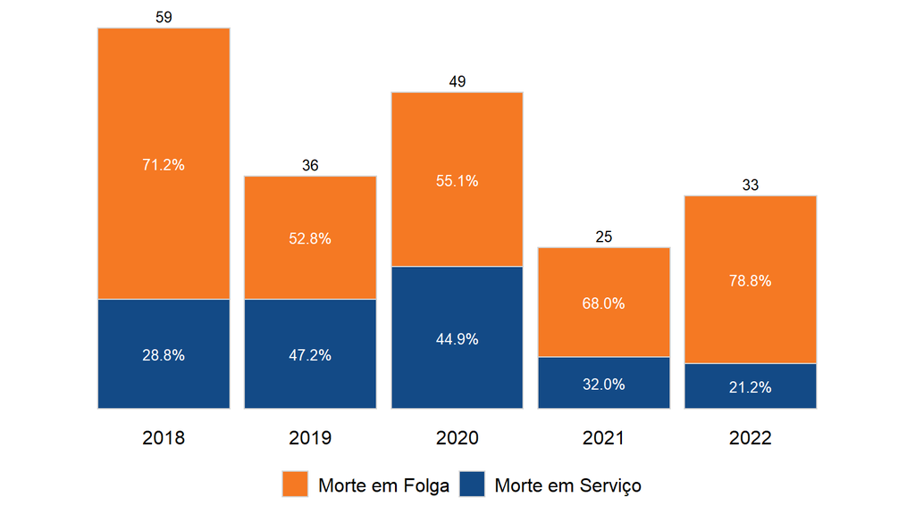

Não apenas o número de policiais mortos reduziu na comparação entre os anos de 2018 e 2022 (ainda que de maneira não uniforme), mas também a proporção destas mortes que ocorreram em períodos de folga e de serviço. As mortes de policiais no estado de São Paulo ocorrem majoritariamente em períodos de folga, ainda que esta proporção varie de 52,8% em 2019, ano em que mais a dinâmica proporcional das mortes em serviço e folga se aproximou, até 78,8% em 2022. No período de cinco anos entre 2018 e 2022, 202 policiais do estado de São Paulo foram mortos, sendo 71 em serviço (35%) e 131 (65%) em períodos de folga. Neste sentido, o ano de 2022 se destaca ainda mais como aquele com menor proporção de vitimização policial em serviço.

Vitimização policial antes e depois das COPs

Vitimização policial por Região

Entre 2018-2022

| Cop | Total | Morte em Serviço | Morte em Folga |
| --- | --- | --- | --- |
| Capital |  |  |  |
| Antes das COPs | 52 | 30.77 | 69.23 |
| Depois das COPs | 24 | 12.50 | 87.50 |
| Estado |  |  |  |
| Antes das COPs | 95 | 35.79 | 64.21 |
| Depois das COPs | 58 | 25.86 | 74.14 |
| Interior |  |  |  |
| Antes das COPs | 30 | 43.33 | 56.67 |
| Depois das COPs | 22 | 45.45 | 54.55 |
| Região Metropolitana |  |  |  |
| Antes das COPs | 13 | 38.46 | 61.54 |
| Depois das COPs | 12 | 16.67 | 83.33 |

Letalidade policial por Região

Entre 2018-2022

| Cop | Total | Morte em Serviço | Morte em Folga |
| --- | --- | --- | --- |
| Capital |  |  |  |
| Antes das COPs | 817 | 73.44 | 26.56 |
| Depois das COPs | 480 | 58.75 | 41.25 |
| Estado |  |  |  |
| Antes das COPs | 1746 | 79.78 | 20.22 |
| Depois das COPs | 1013 | 70.58 | 29.42 |
| Interior |  |  |  |
| Antes das COPs | 586 | 89.25 | 10.75 |
| Depois das COPs | 346 | 86.42 | 13.58 |
| Região Metropolitana |  |  |  |
| Antes das COPs | 343 | 78.72 | 21.28 |
| Depois das COPs | 187 | 71.66 | 28.34 |

Os anos de 2018 e 2019, antes da implementação das Câmeras Corporais Operacionais (COPs), registraram um total de 95 mortes de agentes de segurança em todo o estado, com a capital paulista sendo a região com a maior quantidade, 52 casos (54,7% do total de mortes).

Porém, nos anos de 2021 e 2022, após a implantação das COPs e demais medidas de mitigação do uso da força pela PMSP, o estado teve um total de 58 mortes de policiais, uma redução de 39% no número de vitimizações de agentes de segurança.

Participação da letalidade policial na letalidade violenta por macrorregião

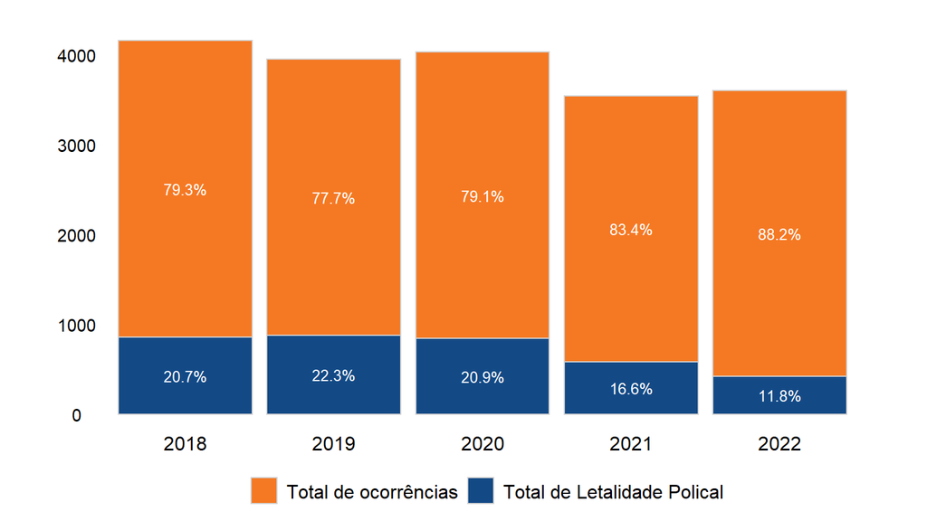

Com a queda da letalidade policial, há uma significativa redução da participação policial no total de ocorrências letais no estado. No ano de 2018 a letalidade policial era responsável por 20,7% das mortes violentas intencionais (soma de latrocínios, homicídios dolosos, lesões seguidas de mortes e das próprias mortes cometidas por policiais) do estado de São Paulo. Em 2022, após a intensa redução das mortes em decorrência de intervenção policial, as mortes cometidas por policiais passaram a representar 11,8% do total de mortes violentas intencionais no estado.

Proporção entre vitimização e letalidade policial por macrorregião

Vitimização policial por Região

2018 e 2022

|  | Letalidade Policial | Vitimização Policial | Proporção |
| --- | --- | --- | --- |
| 2018 |  |  |  |
| Capital | 411 | 29 | 14.2 / 1 |
| Estado de São Paulo | 863 | 59 | 14.6 / 1 |
| Grande São Paulo | 173 | 12 | 14.4 / 1 |
| Interior | 279 | 18 | 15.5 / 1 |
| 2022 |  |  |  |
| Capital | 188 | 17 | 11.1 / 1 |
| Estado de São Paulo | 425 | 33 | 12.9 / 1 |
| Grande São Paulo | 61 | 6 | 10.2 / 1 |
| Interior | 176 | 10 | 17.6 / 1 |

No intervalo entre 2018 e 2022, o número de vítimas de letalidade policial no estado teve uma redução de -50,7%, enquanto a vitimização de policiais em serviço e de folga, caiu -44%: 59 policiais foram mortos no estado em 2018, contra 33 policiais vitimados em 2022.

Especialistas em violência policial, como Paul Chevigny, partindo do pressuposto que as polícias devem empregar força adequada e proporcional ao perigo que correm em situações de risco, o número de pessoas mortas para cada policial morto se torna um indicador importante para avaliação sobre o uso da força policial. Segundo Chevigny, quando essa proporção supera 15:1, é possível que a força letal esteja sendo utilizada para fins outros que não a preservação da vida.

No ano de 2018, tanto o estado como suas macroregiões tiveram, somadas as mortes cometidas e sofridas por policiais em serviço e fora de serviço, proporções muito próximas de 15 pessoas mortas pelas polícias para cada policial vitimado. Já no ano de 2022 se viu uma redução nesta proporção no estado, na Capital e nos municípios da Grande São Paulo, mas com um aumento no Interior, que registrou uma proporção de 17.6 pessoas mortas pelas polícias para 1 policial morto. Esta mudança aponta para a peculiaridade do Interior do estado, onde a vitimização policial (-44,4% no período) se reduziu de maneira mais intensa que a letalidade policial (-36,9%) nos últimos cinco anos.

Ocorrências de letalidade policial com 2 ou mais vítimas

Ocorrências com mais de uma vítima

Entre 2018-2022

| Ano | Casos |
| --- | --- |
| 2018 | 16 |
| 2019 | 20 |
| 2020 | 17 |
| 2021 | 8 |
| 2022 | 3 |

Além da redução das mortes cometidas por policiais entre os anos de 2018 a 2022, também é possível identificar uma forte queda no número de ocorrências em que mais de uma pessoa foi vitimizada em decorrência de intervenção policial. Nos anos de 2018 e 2019 somados, o estado registrou 36 ocorrências de morte decorrente de intervenção policial com 2 ou mais vítimas. Já em 2021 e 2022, após a implementação das câmeras corporais e das demais medidas de controle do uso da força policial, foram registrados 11 casos de mortes cometidas por policiais com mais de uma vítima, uma redução expressiva de -69,4% nas ocorrências com mais de uma vítima fatal.

Mapas das ocorrências de letalidade policial por ano em serviço e fora de serviço na cidade de São Paulo - 2018 a 2022

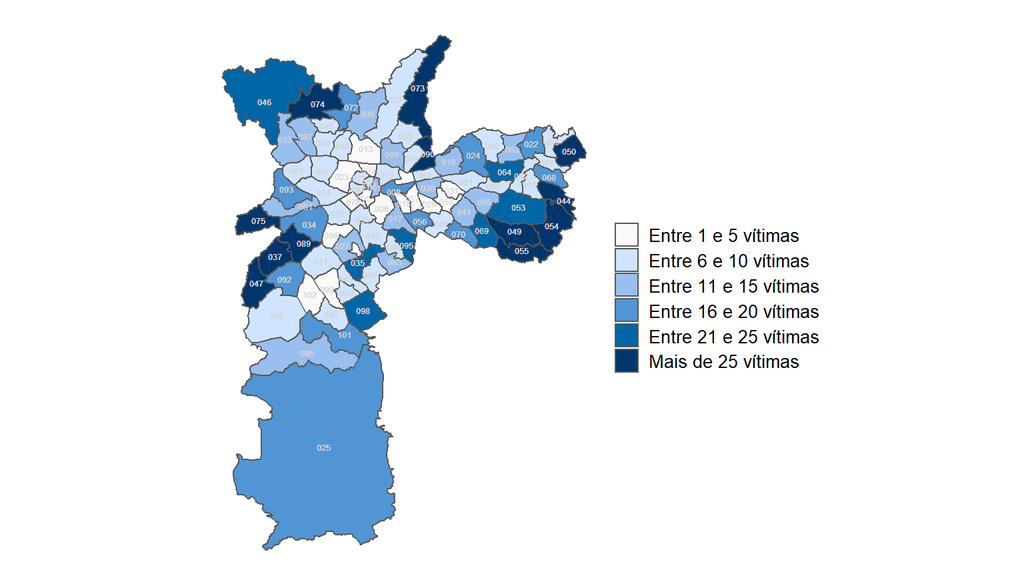

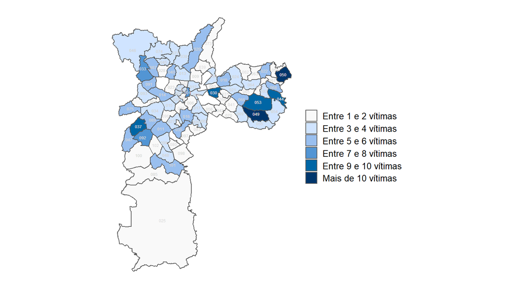

Mapas das ocorrências de letalidade policial em São Paulo

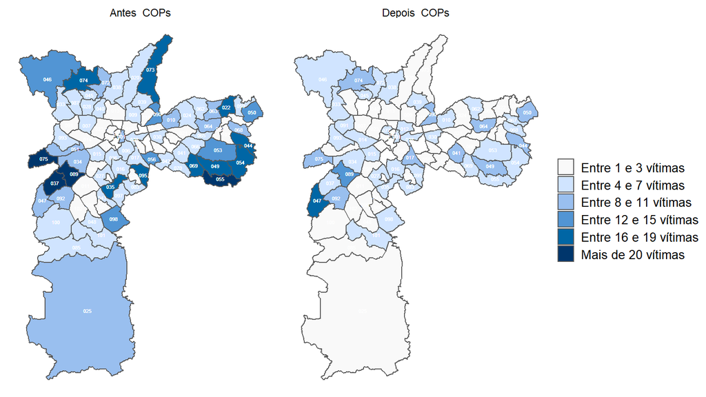

Somadas as mortes cometidas pelas polícias na cidade de São Paulo nos anos de 2018 e 2019, foram registradas 817 vítimas letais. Já nos anos de 2021 e 2022 foram 480 pessoas mortas, uma redução de 41% vítimas.

No período antes da implementação do programa Olho Vivo, 10 dos 93 DPs da capital foram responsáveis por 188 vítimas (23% do total do período). Quatro DPs registraram mais de 20 vítimas em 2018 e 2019: 037 DP - Campo Limpo, e 089 DP - Portal do Morumbi, ambos na zona sul, com, respectivamente 24 e 22 mortos, 055 DP - Parque São Rafael, na zona leste, com 075 DP - Jardim Arpoador, na zona oeste, ambos com 21 vítimas.

Perfil etário das vitímas de MDIP

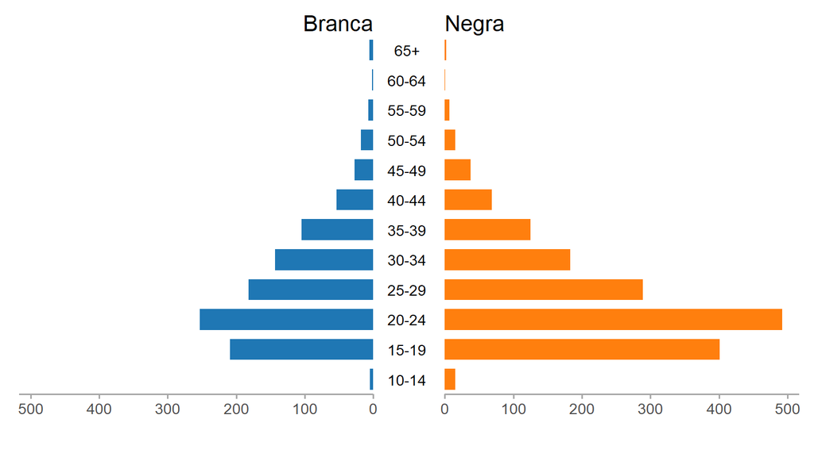

Das 3.603 pessoas mortas em Mortes Decorrente de Intervenção Policial (MDIP) no período entre 2018 e 2022, foram disponibilizados dados de raça de 3.321 destas vítimas. Destas, 2. 147 (64,6%) eram pessoas negras, de acordo com a aglutinação das classificações raciais e de faixa etária do IBGE, e 1.174 (35,4%) das vítimas foram consideradas brancas.

De acordo com o Censo de 2010, 63,9% dos habitantes paulistas se declararam brancos, 34,6% negros (pretos e pardos). Com isso, nota-se que existe uma inversão entre a proporção da população negra do estado, e sua sobrerrepresentação dentre as vítimas de mortes decorrentes de intervenção policial.

A população jovem (15 a 29 anos) é também a maior vitimada nos casos de MDIP. O perfil racial e etário das vítimas segue a mesma dinâmica nacional, conforme podemos observar na segunda edição do relatório Violência Armada e Racismo, do Instituto Sou da Paz.

Perfil etário das vitímas de MDIP

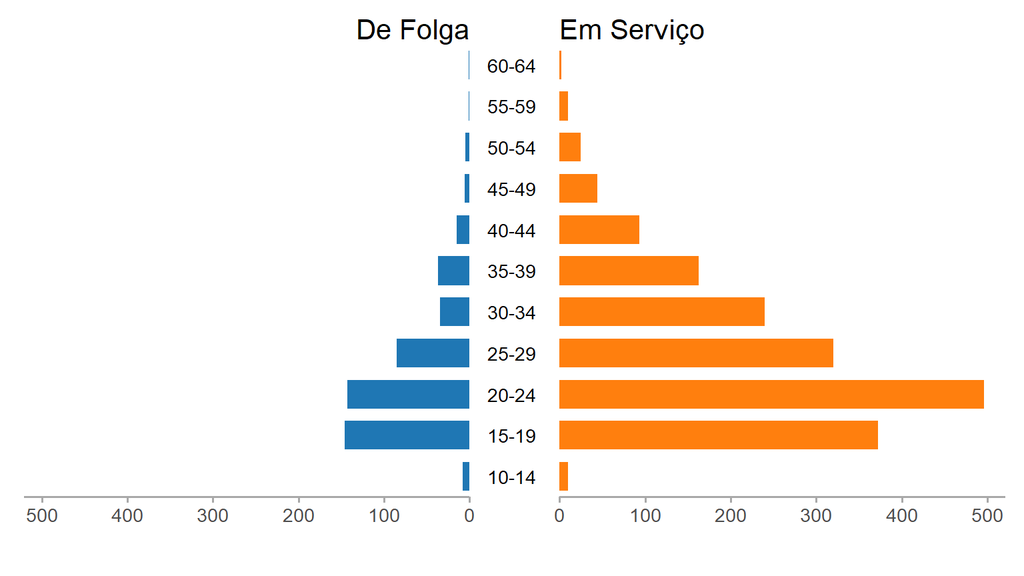

Do total de 3.603 vítimas de letalidade policial no período entre 2018 e 2022, foram disponibilizados os dados etários de 2.257 vítimas. E ao analisar o perfil etário das mortes cometidas por policiais em serviço e de folga no período, é possível identificar padrões distintos na idade das vítimas.

Dentre as 1.775 pessoas vitimadas por policiais em serviço, 382 vítimas (21,5%) tinham até 19 anos de idade, e 816 mortos (45,8%) tinham idades entre 20 e 29 anos.

Já entre as 482 pessoas mortas por policiais em folga, 154 (31,9%) tinham entre 10 e 19 anos, e 228 vítimas (47,3%) tinham entre 20 e 29 anos de idade. Ou seja, ainda que o número absoluto de jovens mortos por policiais em serviço seja maior, uma maior proporção de adolescentes e jovens tende a ser morta por policiais de folga.

Analisamos o perfil etário das mortes cometidas por policiais de folga e em serviço nos períodos antes da implementação das medidas de controle do uso da força e do programa Olho Vivo pela PMSP (em 2018 e 2019), e nos dois anos imediatamente após o início destas medidas (2021 e 2022).

No período anterior as medidas de controle do uso da força pela PMSP, um quarto (24,8%) das vítimas de morte decorrentes de intervenção policial em serviço tinham entre 10 e 19 anos de idade. As vítimas com idade entre 20 e 29 anos compunham 43,8% do total das pessoas mortas por policiais em serviço. Já dentre as mortes cometidas por policiais de folga, um terço (31,9%) vitimaram jovens até 19 anos, e as vítimas entre 20 e 29 anos foram 45,4% do total de vítimas de letalidade policial em folga.

Já em 2021 e 2022, período posterior a implementação das medidas de controle do uso da força pela PMSP, 17% das vítimas de morte decorrentes de intervenção policial em serviço no estado de São Paulo tinha entre 10 e 19 anos, enquanto as vítimas com idades entre 20 e 29 anos representaram 49,6% do total de pessoas mortas por policiais em serviço nestes dois anos. Dentre os casos de MDIP cometidos por policiais de folga nos anos de 2021 e 2022, as vítimas com menos de 19 anos representam 30,5% do total, enquanto as pessoas com idade entre 20 e 29 anos foram 48,9% das vítimas de policiais de folga no período.

Na comparação da composição percentual das vítimas de letalidade policial de acordo com sua faixa etária, foi perceptível no período após a implementação das medidas de controle do uso da força e do programa Olho Vivo pela PMSP (2021 e 2022), uma redução mais concentrada da vitimização de adolescentes e jovens até 19 anos – uma redução percentual de 7,8% na participação destas vítimas no total dos mortos por policiais em serviço após a implementação do programa Olho Vivo. Mas em relação as vítimas de 10 a 19 anos nas ocorrências de letalidade por policiais de folga, esta redução proporcional foi muito menor, de apenas 1,4% na comparação entre os períodos antes e depois da implementação das medidas de controle do uso da força e do programa Olho Vivo pela PMSP.

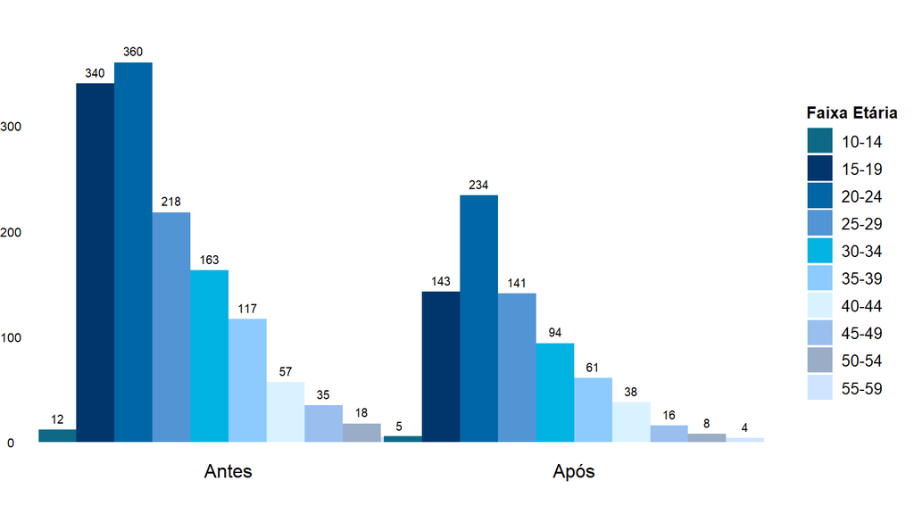

O gráfico apresenta uma análise do perfil etário das vítimas de letalidade policial (em serviço e de folga) no estado de São Paulo.

Nos dois anos (2018 e 2019) antes da implementação das medidas de controle do uso da força, sobretudo o Programa Olho Vivo, pela PMESP, era pequena a diferença do número de mortos das duas faixas etárias mais vitimadas: de 15 a 19 anos, e de 20 a 24 anos. Ao todo foram 1.325 vítimas em 2 anos.

No período de dois anos (2021 e 2022) após a implementação do programa Olho Vivo, houveram 745 vítimas de letalidade policial, uma significativa redução de -44% na comparação com o período anterior. Todas as faixas etárias tiveram redução no número de vítimas, a maior se concentrando na faixa etária de 15 a 19 anos, com 197 vítimas a menos (-58%).

No total, foram 407 mortes de adolescentes e jovens de 0 a 29 anos pelas polícias do estado a menos na comparação com o período anterior às medidas de controle do uso da força pela PMESP.

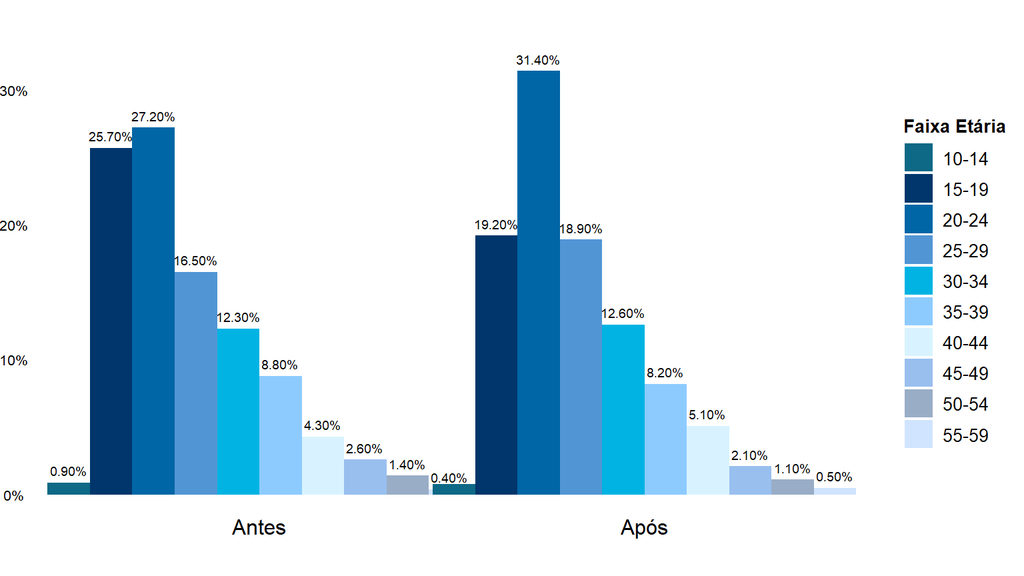

Este gráfico apresenta os mesmos dados acerca do perfil etário das vítimas de letalidade policial (em serviço e de folga) no estado de São Paulo, mas com foco na proporção percentual de vítimas de cada faixa etária, antes e após a implementação das medidas de controle do uso da força, pela PMESP.

Nos dois anos (2018 e 2019) antes da implementação das medidas de controle do uso da força, as vítimas de 10 a 19 anos representaram 26,6% de todas as vítimas de letalidade policial no estado. Ou seja, 1 a cada 4 pessoas mortas pelas polícias eram adolescentes ou jovens.

No período (2021 e 2022) após a implementação do programa Olho Vivo, não só o número absoluto de vítimas caiu, mas a participação de vítimas de 10 a 19 anos cairam para 19,6% de todas as vítimas de letalidade policial no estado no período. Proporcionalmente, houve um aumento das vítimas de 20 a 34 anos após a implementação destas medidas.

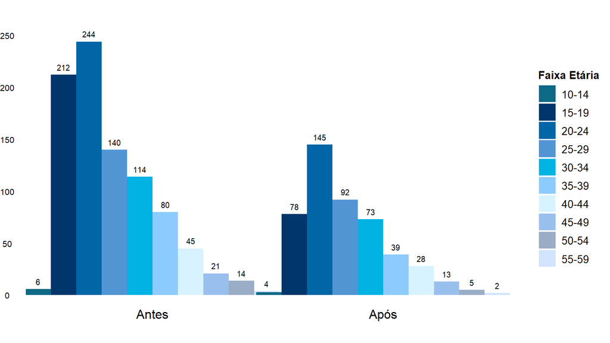

Também nos interessa comparar o efeito da implementação das medidas de controle do uso da força pela PMESP no perfil etário das vítimas de policiais em serviço e em folga. Como esperado, houve uma grande redução no número de vítimas de letalidade policial em serviço em todas as faixas etárias, sobretudo entre jovens.

Foram 212 vítimas com idade entre 15 e 19 anos no período anterior (2018 e 2019) a implementação das medidas de controle da força. Já no período de dois anos após a implementação foram 78 vítimas de 15 a 19 anos, uma intensa redução de -63,2%. Entre as vítimas com idades entre 20 e 24 anos, o número de mortes caiu de 244 vítimas para 145 vítimas na comparação entre os períodos, uma redução de -40,5%.

No total, considerados apenas as mortes com informações sobre a faixa etária, foram 880 mortes cometidas por policiais em serviço em 2018 e 2019, e 478 vítimas nos anos de 2021 e 2022, uma queda na letalidade em serviço de -45,6%

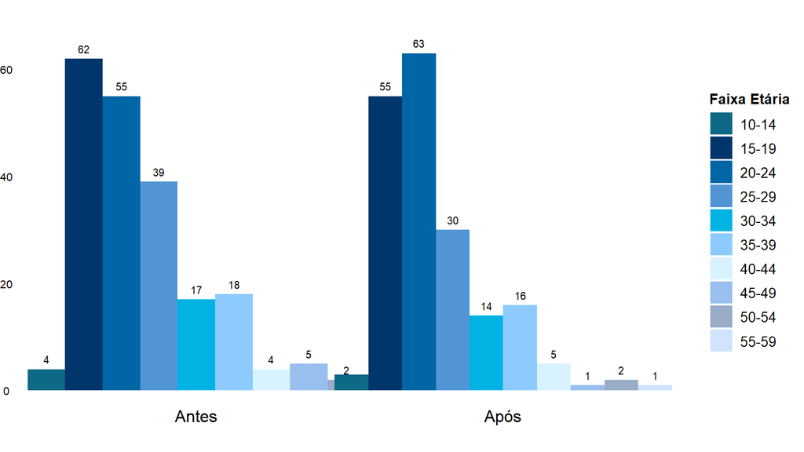

O efeito da implementação das medidas de controle do uso da força pela PMESP no perfil etário das vítimas de policiais em folga foi muito baixo. O que faz sentido, já que estas ocorrências se relacionam mais com a dinâmica de roubos, conflitos interpessoais e trabalhos pontuais realizados por policiais.

Foram 62 vítimas com idade entre 15 e 19 anos no período anterior (2018 e 2019) a implementação das medidas de controle da força. Já no período de dois anos após a implementação foram 55 vítimas adolescentes, uma queda de -11,2%. Entre as vítimas com idades entre 20 e 24 anos, o número de mortes aumentou de 55 vítimas para 63 mortes na comparação entre os períodos, um crescimento de 14,5% na letalidade de pessoas nesta faixa etária.

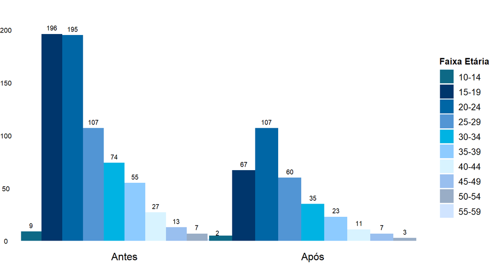

Finalmente nos interessa recortar somente dos batalhões da PMESP que integram o Programa Olho Vivo, ou seja, cujos policiais utilizam as Câmeras Operacionais Portáteis (COP) em serviço. Como mencionado anteriormente, o Programa Olho Vivo foi implementado, sobretudo nos batalhões da Capital e Grande São Paulo, em unidades com elevada letalidade em serviço. Desta forma, o gráfico compara o perfil etário das vítimas de letalidade destes batalhões antes e depois da implementação das COP.

Novamente a maior redução da letalidade se deu entre as vítimas com idade entre 10 e 19 anos. Nos dois anos (2018 e 2019) antes da implementação das medidas de controle do uso da força, estes batalhões foram responsáveis pela morte de 205 crianças e adolescentes de 0 a 19 anos.

No período de dois anos após a implementação do programa Olho Vivo, os mesmos batalhões foram responsáveis por 69 vítimas letais entre 0 e 19 anos, uma redução de -66,3% na letalidade de crianças e adolescentes.

Perfil racial e etário das vítimas de letalidade policial em São Paulo

Proporção de Raça/Cor

Entre 2018-2022

| Raça/Cor | Total | Frequência |
| --- | --- | --- |
| Amarela | 3 | 0.09 |
| Branca | 1174 | 34.66 |
| NA | 63 | 1.86 |
| Negra | 2147 | 63.39 |

Diversos estudos têm observado ao longos dos anos como o perfil de quem mais sofre com a letalidade policial é o mesmo da violência letal no Brasil: jovens homens negros. Dentre o total de 3.387 vítimas de MDIP no período analisado, observa-se que 2.147 são de pessoas negras — 63,4% —, enquanto pessoas brancas contabilizam 1.174 das vitimizações pela polícia no período, equivalente a 34,7% do total.

Em 63 casos não houve preenchimento da categoria de raça e, houve três casos em que a cor/raça das vítimas foram identificadas como amarelas, representando menos de 0,1% dos casos.

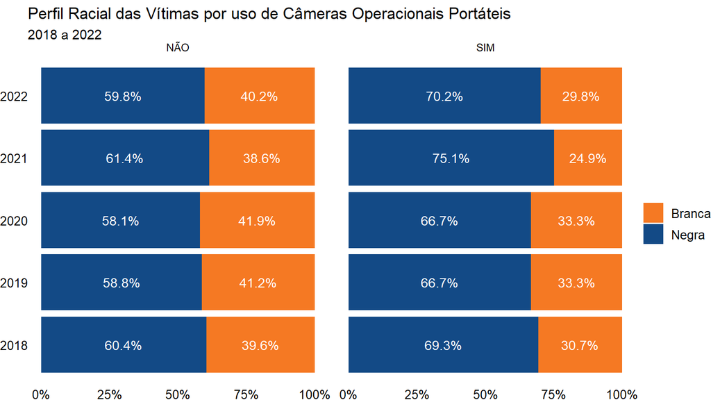

Top 10 bairros da Cidade de São Paulo com mais MDIPs

Período entre 2018-2022

| Bairro | Negra | Branca | Total |
| --- | --- | --- | --- |
| Sacomã | 17 | 12 | 29 |
| Cidade Tiradentes | 23 | 4 | 27 |
| Grajaú | 21 | 6 | 27 |
| Iguatemi | 19 | 8 | 27 |
| São Rafael | 21 | 6 | 27 |
| Sapopemba | 13 | 11 | 24 |
| Raposo Tavares | 14 | 9 | 23 |
| Vila Andrade | 13 | 10 | 23 |
| Capão Redondo | 13 | 9 | 22 |
| Itaim Paulista | 19 | 3 | 22 |

Bairros

Dentre as ocorrências na capital, nota-se uma concentração de casos em bairros da zona leste e zona sul da cidade. Os bairros com maior ocorrência de MDIPs na cidade de São Paulo, são também bairros com alta concentração de moradores negros, conforme os dados divulgados pelo Mapa da Desiguldade (referenciar). Grajaú, por exemplo, situado na lista como o segundo bairro com maior concentração da população negra na cidade (56,8%), é o terceiro bairro com maior número de casos de letalidade policial no período analisado. Apesar da população majoritariamente negra, há ainda uma sobrerepresentação de negros vitimados pela polícia na região. Dos 27 casos, 21 das mortes foram de homens negros, representando 77,7% dos casos.

Em todos os bairros, entre os 20 com maiores quantidades de casos, os negros foram vitimados em maior proporção (mais de 50% dos casos) do que brancos.

Batalhões com maior número de MDIPs por Região

Variação entre 2018-2022

|  | Cop | 2018 | 2019 | 2020 | 2021 | 2022 | Total | Variação |
| --- | --- | --- | --- | --- | --- | --- | --- | --- |
| Capital |  |  |  |  |  |  |  |  |
| 1° BPChoque(Rota) | Sim | 36 | 46 | 43 | 18 | 4 | 147 | -73% |
| 16º BPM/M | Sim | 21 | 17 | 12 | 6 | 7 | 63 | -66% |
| 38º BPM/M | Sim | 16 | 17 | 13 | 8 | 0 | 54 | -76% |
| 28º BPM/M | Sim | 5 | 16 | 16 | 4 | 2 | 43 | -71% |
| 4° BAEP | Sim | 11 | 9 | 5 | 3 | 1 | 29 | -80% |
| 23º BPM/M | Sim | 7 | 8 | 2 | 5 | 4 | 26 | -40% |
| 05º BPM/M | Sim | 3 | 12 | 6 | 4 | 0 | 25 | -73% |
| 19º BPM/M | Sim | 7 | 6 | 7 | 5 | 0 | 25 | -62% |
| 43º BPM/M | Sim | 6 | 6 | 10 | 3 | 0 | 25 | -75% |
| 18º BPM/M | Sim | 13 | 3 | 6 | 2 | 0 | 24 | -88% |
| 22º BPM/M | Sim | 4 | 3 | 5 | 3 | 5 | 20 | 14% |
| 46º BPM/M | Sim | 3 | 8 | 4 | 2 | 3 | 20 | -55% |
| 01º BPM/M | Sim | 10 | 5 | 3 | 0 | 1 | 19 | -93% |
| 09º BPM/M | Sim | 1 | 9 | 6 | 1 | 2 | 19 | -70% |
| 21º BPM/M | Sim | 4 | 4 | 7 | 3 | 1 | 19 | -50% |
| 48º BPM/M | Sim | 4 | 4 | 5 | 3 | 3 | 19 | -25% |
| Interior |  |  |  |  |  |  |  |  |
| 2° BAEP | Sim | 2 | 16 | 23 | 10 | 1 | 52 | -39% |
| 1° BPChoque(Rota) | Sim | 8 | 12 | 12 | 11 | 0 | 43 | -45% |
| 48º BPM/I | Sim | 9 | 15 | 16 | 0 | 2 | 42 | -92% |
| 06º BPM/I | Não | 10 | 17 | 4 | 0 | 6 | 37 | -78% |
| 21º BPM/I | Sim | 11 | 3 | 10 | 10 | 2 | 36 | -14% |
| 1°BAEP | Sim | 8 | 6 | 17 | 3 | 0 | 34 | -79% |
| 10º BPM/I | Não | 13 | 8 | 5 | 4 | 4 | 34 | -62% |
| 07º BPM/I | Não | 16 | 8 | 3 | 0 | 2 | 29 | -92% |
| 20º BPM/I | Não | 3 | 2 | 9 | 8 | 5 | 27 | 160% |
| 10° BAEP | Não | 0 | 1 | 13 | 8 | 3 | 25 | 1000% |
| 45º BPM/I | Não | 4 | 6 | 9 | 2 | 2 | 23 | -60% |
| 36º BPM/I | Não | 4 | 7 | 6 | 2 | 3 | 22 | -55% |
| 47º BPM/I | Não | 4 | 6 | 3 | 2 | 7 | 22 | -10% |
| 38º BPM/I | Não | 3 | 4 | 2 | 3 | 9 | 21 | 71% |
| 39º BPM/I | Não | 3 | 5 | 7 | 1 | 3 | 19 | -50% |
| Grande São Paulo |  |  |  |  |  |  |  |  |
| 1° BPChoque(Rota) | Sim | 4 | 23 | 12 | 6 | 1 | 46 | -74% |
| 20º BPM/M | Sim | 12 | 9 | 2 | 5 | 1 | 29 | -71% |
| 44º BPM/M | Não | 4 | 3 | 4 | 17 | 1 | 29 | 157% |
| 5° BAEP | Sim | 5 | 6 | 4 | 11 | 0 | 26 | 0% |
| 33º BPM/M | Sim | 11 | 5 | 7 | 2 | 0 | 25 | -88% |
| 15º BPM/M | Sim | 11 | 6 | 5 | 0 | 2 | 24 | -88% |
| 26º BPM/M | Sim | 5 | 4 | 6 | 3 | 3 | 21 | -33% |
| 32º BPM/M | Sim | 5 | 11 | 4 | 1 | 0 | 21 | -94% |
| 41º BPM/M | Não | 6 | 4 | 7 | 3 | 0 | 20 | -70% |
| 14º BPM/M | Sim | 5 | 1 | 4 | 7 | 2 | 19 | 50% |

Letalidade em serviço dos batalhões da Rota por Região

Variação entre 2018-2022

|  | COP | 2018 | 2019 | 2020 | 2021 | 2022 | Total | Variação |
| --- | --- | --- | --- | --- | --- | --- | --- | --- |
| Capital |  |  |  |  |  |  |  |  |
| 1° BPChoque(Rota) | Sim | 36 | 46 | 43 | 18 | 4 | 147 | -73% |
| Grande São Paulo |  |  |  |  |  |  |  |  |
| 1° BPChoque(Rota) | Sim | 4 | 23 | 12 | 6 | 1 | 46 | -74% |
| Interior |  |  |  |  |  |  |  |  |
| 1° BPChoque(Rota) | Sim | 8 | 12 | 12 | 11 | 0 | 43 | -45% |

Baep com maiores índices de letalidade em serviço

Variação entre 2018-2022

|  | Cop | 2018 | 2019 | 2020 | 2021 | 2022 | Total | Variação |
| --- | --- | --- | --- | --- | --- | --- | --- | --- |
| 2° BAEP | Sim | 2 | 16 | 23 | 10 | 1 | 52 | -39% |
| 1°BAEP | Sim | 8 | 6 | 17 | 3 | 0 | 34 | -79% |
| 4° BAEP | Sim | 11 | 9 | 5 | 3 | 1 | 29 | -80% |
| 5° BAEP | Sim | 5 | 6 | 4 | 11 | 0 | 26 | 0% |
| 10° BAEP* | Não | 0 | 1 | 13 | 8 | 3 | 25 | 200 |
| 6° BAEP* | Sim | 0 | 1 | 9 | 4 | 0 | 14 | -100 |
| 7° BAEP* | Sim | 0 | 2 | 9 | 2 | 0 | 13 | -100 |
| 3° BAEP | Sim | 0 | 5 | 4 | 3 | 0 | 12 | -40% |

* Para os Baep's implementados após 2018 os valores foram recalculados a partir do seu respectivo ano de criação.

Até julho de 2023, 64 dos 135 batalhões da PMESP foram incluídos no Programa Olho Vivo. O preenchimento da variável batalhão em 2.585 dos casos de letalidade policial em serviço possibilitou analisar mais localizadamente como se distribuem estas mortes no estado entre 2018 e 2022.

As próximas páginas apresentam os batalhões com maior letalidade por macrorregião do estado, além de identificarem se estes batalhões fazem parte do Programa Olho Vivo, o número de vítimas em cada ano da série histórica, e a variação percentual na comparação entre o período antes da implentação do programa Olho Vivo e demais medidas de controle do uso da força (2018 e 2019) e o período de dois após a implementação destas medidas (2021 e 2022).

CAPITAL

Dez dos 31 batalhões da PMESP foram responsáveis por 461 mortes em serviço na capital entre 2018 e 2022, o que representa 46,7% das 983 mortes cometidas em serviço. Todos estes dez batalhões tiveram uma forte queda na letalidade nos períodos antes e depois das medidas de controle do uso da força, com uma redução média de 70,4% na letalidade dentre os batalhões mais violentos.

O 1º batalhão de Choque da Rota, foi a unidade da PMESP com mais mortes na cidade de São Paulo, com 147 vítimas entre 2018 e 2022. A unidade teve uma redução de -73% na letalidade em serviço na comparação no período anterior (2018 e 2019) e posterior (2021 e 2022) a implementação do programa Olho Vivo e demais medidas de controle do uso da força. Se considerarmos que os padrões de letalidade de 2018 e 2019 teriam se mantido, isso significa que o 1º batalhão de Choque da Rota deixou de matar 60 pessoas em 2021 e 2022.

Dentre os demais batalhões 3 atuam na zona sul (19º BPM/M, 28º BPM/M e 38º BPM/M), 3 atuam na zona norte (5º BPM/M, 18º BPM/M e 43º BPM/M), 2 na zona oeste (16º BPM/M, 23º BPM/M), e um na zona leste (4º BAEP).

GRANDE SÃO PAULO

Dentre os dez da PMESP que compõem o Comando de Policiamento de Área/Metropolitano (CPA/M), sete apresentaram redução na letalidade nos períodos antes e depois das medidas de controle do uso da força. Dentre estes dez BPM, a redução média na letalidade na comparação entre os períodos foi de 31%.

Novamente o 1º batalhão de Choque da Rota, foi a unidade da PMESP com mais mortes - o batalhão atua com maior flexibilidade territorial que os demais BPM. Policiais do 1º BPChoque da Rota em serviço mataram 27 pessoas em 2018 e, principalmente, em 2019 na Grande São Paulo. Nos anos de 2021 e 2022 a letalidade em serviço do batalhão foi de 7 vítimas, uma redução de 74%, similar a redução que o batalhão apresentou na Capital.

Dois BPM apresentaram aumento da letalidade em serviço no período: o 44º BPM (um dos 3 batalhões de Guarulhos), com um impressionante aumento de 157% na letalidade em serviço, e que não faz parte do Programa Olho Vivo; e o 14º BPM (um dos 2 batalhões de Osasco), que registrou um aumento de 50% na letalidade com 3 mortes a mais em 2021 e 2022, e cujos policiais usam as COP.

INTERIOR

Dez dos 63 batalhões da PMESP que compõem o Comando de Policiamento do Interior (CPI) foram responsáveis por 359 mortes em serviço na capital entre 2018 e 2022, o que representa 39% das 922 mortes cometidas em serviço. Dentre estes dez batalhões, oito tiveram reduções na letalidade, e metade integra o Programa Olho Vivo.

A maior letalidade em serviço registrada foi no 2º BAEP, que atua em Santos e na região. A unidade teve uma redução de -39% na letalidade em serviço na comparação no período anterior (208 e 2019) e posterior (2021 e 2022) a implementação do programa Olho Vivo e demais medidas de controle do uso da força. Também registraram mais de 40 vítimas letais no período o 1º batalhão de Choque da Rota e o 48º BPM/I que atende a região de Sumaré, e registrou uma redução de 92% na letalidade na comparação entre os períodos.

É importante ressaltar que batalhões que não fazem parte do programa Olho Vivo, como o 6º BPM/I (Santos), 10º BPM/I (Piracicaba) e 7º BPM/I (Sorocaba) também tiveram reduções significativas na letalidade em serviço.

ROTA Dos 236 registros de mortes cometidas em serviço pelo 1º batalhão de Choque da Rota entre 2018 e 2022, 147 (62,3%) concentraram-se na Capital, 46 (19,5%) na Grande São Paulo, e 43 (18,3%) no Interior.

A redução das mortes em serviço também foi significativa nesse batalhão. Essa queda se torna ainda mais significativa considerando o alto padrão de letalidade do batalhão da rota, já registrada em estudos anteriores (citar). Em todo o estado, em 2018 e 2019 o 1º batalhão de Choque da Rota matou em serviço 129 pessoas. Após a adoção das medidas de controle do uso da força (2021 e 2022), este número caiu para 40 vítimas, uma redução de -69% das mortes em serviço pelo batalhão na comparação entre os períodos.

BAEP

A primeira unidade do Baep (Batalhão de Ações Especiais de Polícia), foi criada em 2014 para ser uma espécie de Rota do Interior, mas hoje estas unidades estão presentes em quase todo Estado de São Paulo, e tiveram uma participação relevante na letalidade policial no período entre 2018 e 2022. Destacamos, sobretudo, a letalidade nos Baep em 2020, ano em que foi verificada queda de vários indicadores de criminalidade.

Dentre os oito Baep que tiveram letalidade mataram mais de dez pessoas no período, apenas um, o 10º BAEP, que atua na região de Piracicaba e demais municípios do Deinter 9, não faz parte do programa Olho Vivo. No entanto é importante observar que este batalhão, tal como o 7° BAEP e o 6° BAEP*, foi criado em meados de 2019, o que pode prejudicar a análise da variação percentual.

O 2º BAEP , que atua na região de Santos, ainda que com uma redução de 39% na letalidade após a implementação do Olho Vivo, segue como o Baep de maior letalidade em serviço. Os outros dois batalhões de maior letalidade, o 1º BAEP (Campinas) e o 4º BAEP (Capital), tiveram respectivamente, expressivas reduções de 79% e 80% no número de mortes.

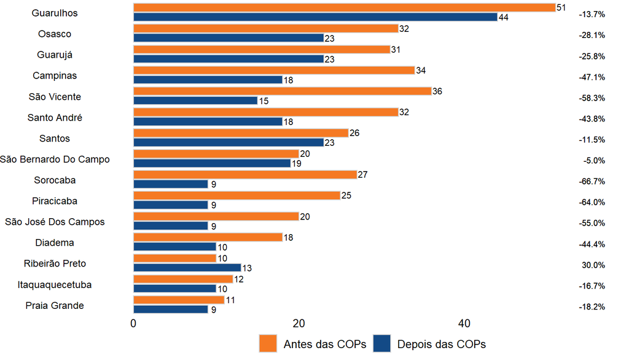

Com exceção da cidade de São Paulo, cuja situação já foi analisada, estes são os 15 municípios com maior letalidade policial (sem serviço e de folga) na comparação dos períodos de 2018 e 2019 (antes da implementação das COP e demais medidas de controle do uso da força pela PMESP), e a letalidade de 2021 e 2022 (após a implementação destas medidas).

Apenas um dos 15 municípios registrou aumento da letalidade no período de 2021 e 2022: Ribeirão Preto, que registrou um aumento de 30% no número de pessoas mortas pelas polícias. É importante ressaltar que o município fica no Comando de Policiamento do Interior de Área Região 3, no qual nenhum batalhão faz parte do Programa Olho Vivo.

Dentre os municípios com maior redução da letalidade policial se destacam Sorocaba, com queda de 66%, Piracicaba, com redução de 64%, São Vicente, com menos 58% mortos, e São José dos Campos, com uma redução de 55% no número de vítimas de letalidade policial.

| ano | COP | n |
| --- | --- | --- |
| 2018 | NÃO | 219 |
| 2018 | SIM | 375 |
| 2019 | NÃO | 219 |
| 2019 | SIM | 445 |
| 2020 | NÃO | 208 |
| 2020 | SIM | 425 |
| 2021 | NÃO | 199 |
| 2021 | SIM | 239 |
| 2022 | NÃO | 168 |
| 2022 | SIM | 106 |

| ano | COP | total | media |
| --- | --- | --- | --- |
| 2018 | NÃO | 219 | 4.211538 |
| 2018 | SIM | 375 | 7.211538 |
| 2019 | NÃO | 219 | 4.211538 |
| 2019 | SIM | 445 | 8.557692 |
| 2020 | NÃO | 208 | 4.000000 |
| 2020 | SIM | 425 | 8.173077 |
| 2021 | NÃO | 199 | 3.826923 |
| 2021 | SIM | 239 | 4.596154 |
| 2022 | NÃO | 168 | 3.230769 |
| 2022 | SIM | 106 | 2.038462 |

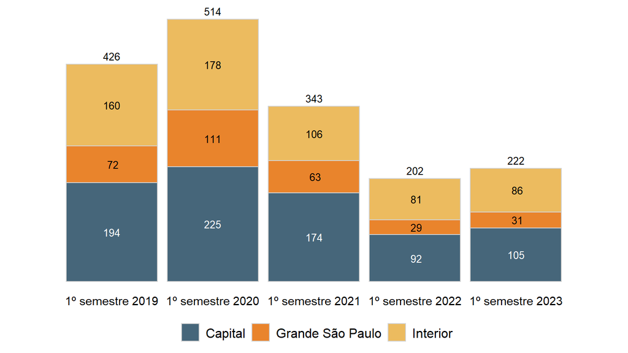

Nos primeiros seis meses do governo Tarcísio as mortes cometidas por policiais voltaram a aumentar após dois anos de intensa queda. O número de vítimas fatais das polícias do Estado de São Paulo foi 10% maior nos primeiros seis meses de 2023 em comparação com o mesmo período do ano anterior: Este aumento da letalidade policial em serviço se concentrou sobretudo na Capital do estado. Houve um aumento de 60% das mortes cometidas por policiais em serviço na cidade de São Paulo, justamente onde há a maior concentração das câmeras operacionais portáteis (COP) do Programa Olha Vivo da PMESP. Ao todo, 72 pessoas foram mortas por policiais em serviço nos primeiros seis meses na capital, contra 45 vítimas fatais de policiais em serviço entre janeiro e junho de 2022.

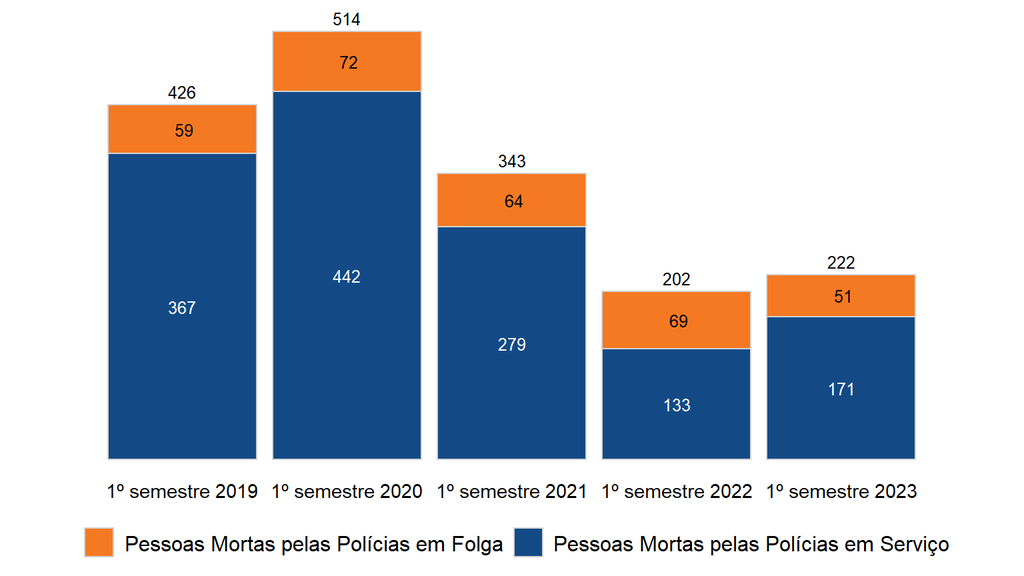

No 1° semestre de 2023 as polícias de São Paulo mataram um total de 222 pessoas: 171 vítimas de policiais em serviço, e 51 pessoas mortas por policiais de folga. Na comparação com o mesmo período do ano anterior, enquanto as mortes cometidas por policiais de folga caíram cerca de 26%, houve um expressivo aumento na letalidade de policiais em serviço:foram 38 vítimas fatais a mais que o mesmo período de 2022, e um crescimento de 28,6% no estado em relação ao primeiro semestre de 2023.

Desta forma, é possível dizer que a letalidade policial no primeiro semestre de 2023 aumentou significativamente, e se concentrou justamente dentre os policiais em serviço e na capital, o que evidencia uma redução da capacidade de redução da letalidade dos mecanismos implementados pela PMESP a partir de meados de 2020.

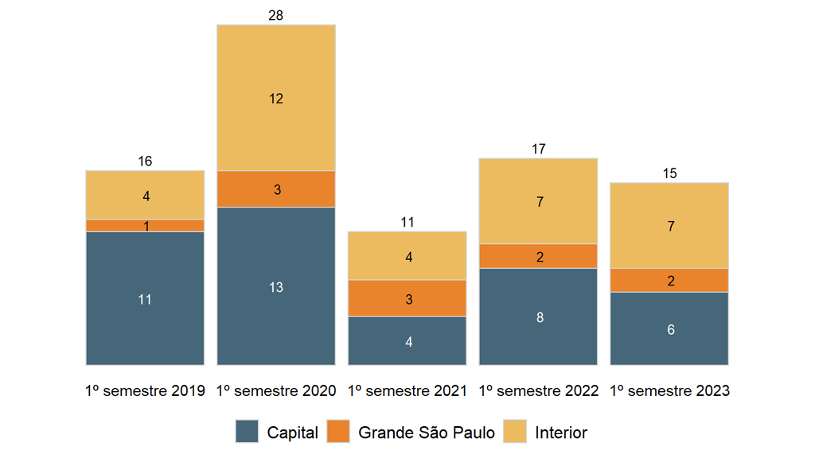

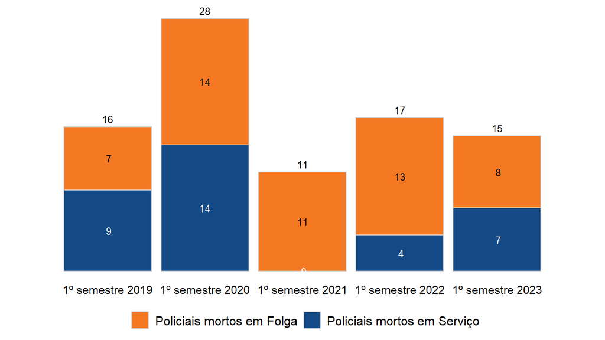